# Actividad 8

# Podemos predecir la diabetes con datos de laboratorio?

Autor: Xavier Duran Albareda Coordinación: Julià Minguillón

PID_00233252

## Introducción

En este ejemplo trataremos el *dataset* [NHANES](https://www.kaggle.com/cdc/national-health-and-nutrition-examination-survey) para predecir la enfermedad de diabetes de tipo 2 a partir de los datos de los análisis de laboratorio. Usaremos el método XGBoost para entrenar el modelo y encontrar las variables con mejor valor predictivo.

[figure not shown]

T2DM

```r
if(!require(ggplot2)){
    install.packages('ggplot2',repos='http://cran.es.r-project.org')
    require(ggplot2)
}
if(!require(readr)){
    install.packages('readr',repos='http://cran.es.r-project.org')
    require(readr)
}
if(!require(data.table)){
    install.packages('data.table',repos='http://cran.es.r-project.org')
    require(data.table)
}
if(!require(dplyr)){
    install.packages('dplyr',repos='http://cran.es.r-project.org')
    require(dplyr)
}
if(!require(xgboost)){
    install.packages('xgboost',repos='http://cran.es.r-project.org')
    require(xgboost)
}
if(!require(caret)){
    install.packages('caret',repos='http://cran.es.r-project.org')
    require(caret)
}
if(!require(pROC)){
    install.packages('pROC',repos='http://cran.es.r-project.org')
    require(pROC)
}
```

## Obtener los datos

Usaremos dos archivos para el análisis. 1. El fichero *medications*, que tiene los diagnósticos donde seleccionaremos los pacientes con diabetes tipo 2. 2. El fichero *labs*, que tiene todas las medidas de laboratorio que serán nuestros predictores.

```r
medications <- fread('medications.csv')
labs <- fread('labs.csv')
```

## Definimos la variable dependiente

El código ICD-10 para la **diabetis melitus Tipus 2** es el **E11**, de forma que crearemos la variable *is_diabetic* para definir aquellos que tienen este código.

Los códigos de diagnóstico ICD-10 se pueden encontrar en el [ICD-10 Browser of the World Health Organization](http://apps.who.int/classifications/icd10/browse/2010/en#/E11)

```r
diabetes <- medications %>%
  mutate(
    is_diabetic = ifelse(RXDRSC1 == 'E11', 1, 0)
  ) %>%
  select(
    SEQN,
    is_diabetic
  ) %>%
  unique() %>%
  left_join(labs)
outcome <- c('is_diabetic')
```

## Definimos las variables independientes o predictores

Todas las variables de laboratorio que tenemos disponibles lo serán.

```r
predictors <- names(diabetes)[!names(diabetes) %in% outcome]
```

## Construimos el modelo

Entrenaremos un modelo XGBoost.

```r
mx.diabetes <- as.matrix(diabetes, rownames.force = NA)
train_dmatrix <- xgb.DMatrix(data = mx.diabetes[, predictors], label = mx.diabetes[, outcome])

fit.xgb <- xgboost(
  data = train_dmatrix,
  nrounds = 10,
  objective = "binary:logistic"
)
```

## Evaluación del modelo

Evaluaremos el modelo en el mismo conjunto de entrenamiento, y después mostraremos la matriz de confusión y la curva ROC.

```r
predictions <- predict(fit.xgb, as.matrix(diabetes[, predictors]))
```

```r
mean(as.numeric(predictions > 0.5) != diabetes[, outcome])
```

```
## [1] 0.05146166
```

```r
confusionMatrix(
  factor(as.numeric(predictions > 0.1)),
  factor(diabetes[, outcome]),
  mode = "everything"
)
```

```
## Confusion Matrix and Statistics
##
##           Reference
## Prediction    0    1
##          0 9309   35
##          1  823  540
##
##                Accuracy : 0.9199
##                  95% CI : (0.9146, 0.9249)
##     No Information Rate : 0.9463
##     P-Value [Acc > NIR] : 1
##
##                   Kappa : 0.5211
##
##  Mcnemar's Test P-Value : <2e-16
##
##             Sensitivity : 0.9188
##             Specificity : 0.9391
##          Pos Pred Value : 0.9963
##          Neg Pred Value : 0.3962
##               Precision : 0.9963
##                  Recall : 0.9188
##                      F1 : 0.9559
##              Prevalence : 0.9463
##          Detection Rate : 0.8694
##    Detection Prevalence : 0.8727
##       Balanced Accuracy : 0.9290
##
##        'Positive' Class : 0
##
```

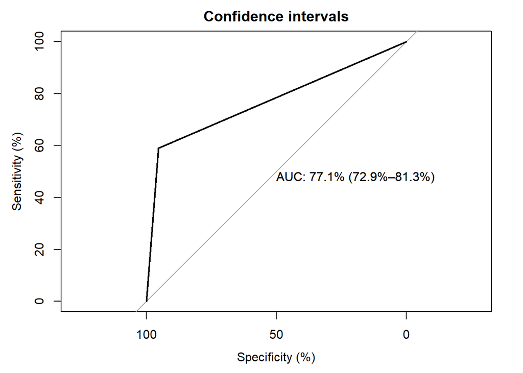

```r
plot.roc(
  as.numeric(predictions > 0.5),
  diabetes[, outcome],
  main = "Confidence intervals",
  percent = TRUE,
  ci = TRUE,
  print.auc=TRUE
)
```

## Variables con más valor predictivo de la diabetes tipo 2

La variable más predictiva es LBXGH, que corresponde al porcentaje de glicohemoglobina respecto el total de hemoglobina, que efectivamente está relacionada con la enfermedad de la diabetis melitus tipo 2.

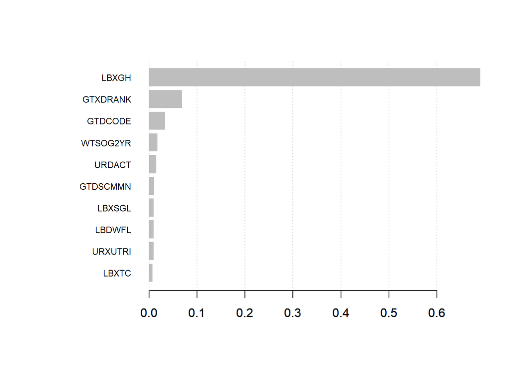

```r
importance_matrix <- xgb.importance(feature_names = predictors, model = fit.xgb)
xgb.plot.importance(importance_matrix[1:10,])
```

```r
head(importance_matrix)
```

```
##     Feature        Gain       Cover  Frequency
## 1:    LBXGH 0.690573210 0.306230723 0.07716049
## 2: GTXDRANK 0.068887975 0.036521306 0.03703704
## 3:  GTDCODE 0.032822747 0.086564383 0.05555556
## 4: WTSOG2YR 0.017641651 0.004561531 0.01851852
## 5:   URDACT 0.014712681 0.086107195 0.04629630
## 6: GTDSCMMN 0.009905424 0.007711531 0.01543210
```